# Homework 2

# Solution Sample

## Part 1: Exam-Style Questions

### Problem 1.1

Write the "full" correlation $J = I \ast I$ of the following $2\times 2$ image with itself, using zero padding. Do *not* normalize.

$$ I = \left[\begin{array}{cc}1 & 2\\0 & 3 \end{array}\right] $$

### Answer

$$ J = \left[\begin{array}{rrr}3 & 6 & 0\\2 & 14 & 2\\0 & 6 & 3 \end{array}\right] $$

### Problem 1.2

Is the following convolution kernel separable? If so, separate it. If not, prove that it is not.

$$ H = \left[\begin{array}{rrr}2 & 0 & 6\\0 & 1 & 0\\1 & 0 & 3 \end{array}\right] $$

### Answer

No, $H$ is not separable. Its first and second column are obviously linearly independent, so $H$ as a matrix has at least rank 2, and can therefore not be written as the product of a column vector and a row vector, as would be required for separability.

### Answer

Then, $$ a \star b = (a_0 b_1, a_0 b_0 + a_1 b_1, a_1 b_0) = (0, 3, 2) $$ while $$ b \star a = (b_0 a_1, b_0 a_0 + b_1 a_1, b_1 a_0) = (2, 3, 0) \;. $$ These two sequences are different, and therefore the "full"correlation does not commute. That is, in general, $$ a \star b \neq b \star a \;. $$

### Problem 1.5

Give a general expression for the relationship between $c$ and $d$. Specifically, how does the generic element $c_i$ of $c$ relate to the generic element $d_j$ of $d$?

No proof is necessary.

### Answer

The two correlations satisfy $$ c_i = d_{-i} \;\;\;\text{for}\;\;\; i = -n,\ldots,-1,0,1,\ldots, n\;. $$ In words (not needed for full credit), the two sequences are the reverse of each other.

## Part 2: Convolution

### Problem 2.1

Write a function with header

```
def convolve(a, b, ctype='same'):
```

that takes two one-dimensional `numpy` arrays `a` and `b` and an optional convolution type specification `ctype` and returns the convolution of the two arrays as a `numpy` array. Assume that sequence `a` is no shorter than sequence `b`.

The possible values for `ctype` are `'full'`, `'same'` (the default), and `'valid'`. For the last two types, `a` is the signal and `b` is the kernel. For instance, `'same'` means that the output has the same size as `a`.

Show your code and the result of running the given test cases, which compare your implementation to `numpy.convolve`. It is OK if the `dtype` of your output differs from that of `numpy.convolve`.

### Answer

```python
import numpy as np
from math import ceil

def convolve(a, b, ctype='same'):
    la, lb = len(a), len(b)
    if ctype is 'full':
        pad = (lb - 1, lb - 1)
    elif ctype is 'same':
        left = ceil((lb-1)/2)
        right = lb - 1 - left
        pad = (left, right)
    elif ctype is 'valid':
        pad = (0, 0)
    else:
        raise ValueError("Unknown convolution type '" + ctype + "'")
    ap = np.zeros(pad[0] + la + pad[1])
    ap[pad[0]:(pad[0] + la)] = a
    lc = len(ap) - lb + 1
    if lc <= 0: return np.empty(0)
    c = np.zeros(lc)
    for i in range(len(c)):
        for j in range(lb):
            c[i] += ap[i + lb - 1 - j] * b[j]
    return c
```

```python
import numpy as np

signal = np.array([2, 1, -3, 0, 5])
kernel = np.array([2, 0, -1, -2])
ctypes = ('full', 'same', 'valid')

try:
    print('convolve:')
    for ctype in ctypes:
        print(ctype, ': ', convolve(signal, kernel, ctype), sep='')
    print()

    print('numpy.convolve:')
    for ctype in ctypes:
        print(ctype, ': ', np.convolve(signal, kernel, ctype), sep='')
    print()
except NameError:
    pass
```

```
convolve:
full: [  4.   2.  -8.  -5.  11.   6.  -5. -10.]
same: [ 2. -8. -5. 11.  6.]
valid: [-5. 11.]

numpy.convolve:
full: [  4   2  -8  -5  11   6  -5 -10]
same: [ 2 -8 -5 11  6]
valid: [-5 11]
```

### Problem 2.2

Write a function with header

```
def convolve2d(I, H):
```

that takes a two-dimensional numerical `numpy` array `I` and a two-dimensional numerical `numpy` array `H`, both non-empty, *and uses* `np.convolve` (the `numpy` one-dimensional convolution function) to implement the (two-dimensional) convolution of `I` and `H` of style `same`. Do *not* use any other convolution operators.

Show your code and the result of running the given test cases, which compare your implementation to `scipy.signal.convolve2d` when called with the `'same'` option. It is OK if the `dtype` of your output differs from that of `scipy.signal.convolve2d`.

### Answer

```python
from math import floor

def convolve2d(I, H):
    irows, hrows = I.shape[0], H.shape[0]
    trows = floor(hrows/2)
    J = np.zeros_like(I, dtype=float)
    for u in range(hrows):
        for ri in range(irows):
            ro = ri + u + trows - hrows + 1
            if ro >= 0 and ro < irows:
                J[ro] += np.convolve(I[ri], H[u], 'same')
    return J
```

```python
from scipy import signal as ss
import numpy as np

a = np.array([[10, 11, 12],
              [20, 21, 22],
              [30, 31, 32]])
hList = (np. array([[1]]), np.array([[1, -2]]), np.array([[2], [-1]]),
         np.array([[2, 3, 5], [4, 0, 1]]), np.array([[2, 3, 5], [4, 0, 1], [1, -1, 2]]))

try:
    for h in hList:
        c = convolve2d(a, h)
        s = ss.convolve2d(a, h, 'same')

        print('----')
        print('convolve2d:', c, sep='\n', end='\n\n')
        print('scipy.signal.convolve2d:', s, sep='\n', end='\n\n')
except NameError:
    pass
```

```
----
convolve2d:
[[10. 11. 12.]
 [20. 21. 22.]
 [30. 31. 32.]]

scipy.signal.convolve2d:
[[10 11 12]
 [20 21 22]
 [30 31 32]]

----
convolve2d:
[[ 10.  -9. -10.]
 [ 20. -19. -20.]
 [ 30. -29. -30.]]

scipy.signal.convolve2d:
[[ 10  -9 -10]
 [ 20 -19 -20]
 [ 30 -29 -30]]

----
convolve2d:
[[20. 22. 24.]
 [30. 31. 32.]
 [40. 41. 42.]]

scipy.signal.convolve2d:
[[20 22 24]
 [30 31 32]
 [40 41 42]]

----
convolve2d:
[[ 52. 107.  91.]
 [146. 265. 182.]
 [236. 415. 272.]]

scipy.signal.convolve2d:
[[ 52 107  91]
 [146 265 182]
 [236 415 272]]

----
convolve2d:
[[146. 265. 182.]
 [237. 436. 282.]
 [125. 199.  51.]]

scipy.signal.convolve2d:
[[146 265 182]
 [237 436 282]
 [125 199  51]]
```

## Part 3: Image Differentiation

### Problem 3.1

Implement two functions with headers

```
def Gaussian(sigma):
```

and

```
def dGaussian(sigma):
```

that return a one-dimensional truncated discrete Gaussian convolution kernel and its derivative (the two kernels $g(x)$ and $d(x)$ from the class notes). Both kernels take the parameter $\sigma$ of the Gaussian as argument. The output of each function should be a `numpy` array (like the one that `scipy.signal.gaussian` returns) that contains the values of the function at integer points of their domain in the interval $[-a, a]$ where $a = \text{ceil}(3.5\sigma)$ (use `math.ceil`). The output kernels should be properly normalized, as explained in the class notes.

Show your code and a plot of each function with $\sigma = 2.3$. No labels are needed, but plot the Gaussian first. Use the `'.-'` line style option.

Remember to use

```
%matplotlib inline
```

as you did in homework 1.

### Answer

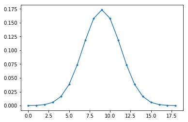

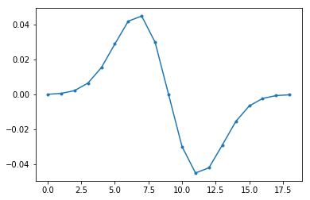

```python
def Gaussian(sigma):
    n = 2 * ceil(3.5 * sigma) + 1
    g = ss.gaussian(n, sigma)
    return g / sum(g)

def dGaussian(sigma):
    g = Gaussian(sigma)
    n = len(g)
    mx = (n - 1) / 2
    x = np.linspace(-mx, mx, n)
    dg = x * g
    kd = 1 / sum(x * dg)
    return -kd * dg

sigma = 2.3
g = Gaussian(sigma)
d = dGaussian(sigma)

from matplotlib import pyplot as plt
%matplotlib inline

plt.plot(g, '.-')
plt.show()

plt.plot(d, '.-')
plt.show()
```

### Problem 3.2

Write a function with header

```
def gradient(img, sigma=2.5):
```

that computes the gradient of the black-and-white image `img` (a two-dimensional `numpy` array). Your implementation should use the function `scipy.signal.convolve2d` and the kernel functions you wrote for the previous problem. The result should be a pair (that is, a Python tuple of length 2) of `numpy` arrays, each of the same size as `img`. The first array in the pair should be the derivative in the horizontal direction.

The positive coordinate axes are horizontal to the right and vertical down. Make sure you get the signs of the derivatives right, given this convention.

The function `scipy.signal.convolve2d` takes a 2-dimensional kernel, but you *must* exploit separability of the differentiation kernels for full credit, so you will be calling this function with kernels that are either $k\times 1$ or $1\times k$ for some $k$.

Show your code, and display the `locomotive.jpg` image (provided) and the two gradient images for it. Use the default value of `sigma`, and use `matplotlib.pyplot.imshow` for display.

### Answer

[figure not shown]

[figure not shown]

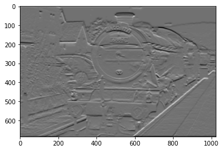

```python
def expand(f, direction):
    assert f.ndim == 1, 'Input f must be one-dimensional'
    if direction is 'vertical':
        return np.expand_dims(f, axis=1)
    elif direction is 'horizontal':
        return np.expand_dims(f, axis=0)
    else:
        raise ValueError("Invalid direction '" + direction + "'")

def gradient(img, sigma=2.5):
    g, d = Gaussian(sigma), dGaussian(sigma)
    gx, gy = expand(g, 'horizontal'), expand(g, 'vertical')
    dx, dy = expand(d, 'horizontal'), expand(d, 'vertical')
    gradx = ss.convolve2d(ss.convolve2d(img, dx, 'same'), gy, 'same')
    grady = ss.convolve2d(ss.convolve2d(img, gx, 'same'), dy, 'same')
    return (gradx, grady)

from skimage import io

img = io.imread('locomotive.jpg')
plt.imshow(img, cmap='gray')
plt.show()

grad = gradient(img)

plt.imshow(grad[0], cmap='gray')
plt.show()

plt.imshow(grad[1], cmap='gray')
plt.show()
```

### Problem 3.3

Compute and display the magnitude of the gradient for `locomotive.jpg`. Show your code and the output.

### Answer

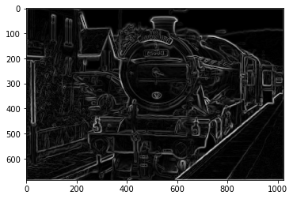

```python
gmag = np.sqrt(grad[0] ** 2 + grad[1] ** 2)

plt.imshow(gmag, cmap='gray')
plt.show()
```